# R Notebook

Use k-means clustering to investigate potential relationships in the dataset students_big from the CodeClanData library.

```r
library(tidyverse)
```

```r
student <- CodeClanData::students_big
student_short <- student %>% select(starts_with("importance")) %>%
  mutate(across(.fns = scale))
```

1 Part a We’ve been asked to create clusters of students for the answers to the ‘importance’ questions (where students rate how important they find certain topics on a scale from 0 to 1000, the higher the number the more important they think the issue is).

If we are to use the mathematical methods (elbow etc.) what would your optimal value of k been? Do you think the data seems well suited to cluster.

```r
library(broom)
max_k <- 20
k_clusters <- tibble(k = 1:max_k) %>%
  mutate(
    kclust = map(k, ~ kmeans(student_short, .x, nstart = 25)),
    glanced = map(kclust, glance)
  ) %>% unnest(glanced)
k_clusters
```

| k | kclust | totss | tot.withinss | betweenss | iter |
| --- | --- | --- | --- | --- | --- |
| 1 |  | 5466 | 5466.000 | 5.547918e-11 | 1 |
| 2 |  | 5466 | 3901.655 | 1.564345e+03 | 1 |
| 3 |  | 5466 | 3059.523 | 2.406477e+03 | 4 |
| 4 |  | 5466 | 2655.296 | 2.810704e+03 | 4 |
| 5 |  | 5466 | 2355.613 | 3.110387e+03 | 7 |
| 6 |  | 5466 | 2188.281 | 3.277719e+03 | 5 |
| 7 |  | 5466 | 2042.142 | 3.423858e+03 | 4 |
| 8 |  | 5466 | 1910.815 | 3.555185e+03 | 6 |
| 9 |  | 5466 | 1814.501 | 3.651499e+03 | 10 |
| 10 |  | 5466 | 1732.623 | 3.733377e+03 | 5 |

[output cut: 10 more lines]

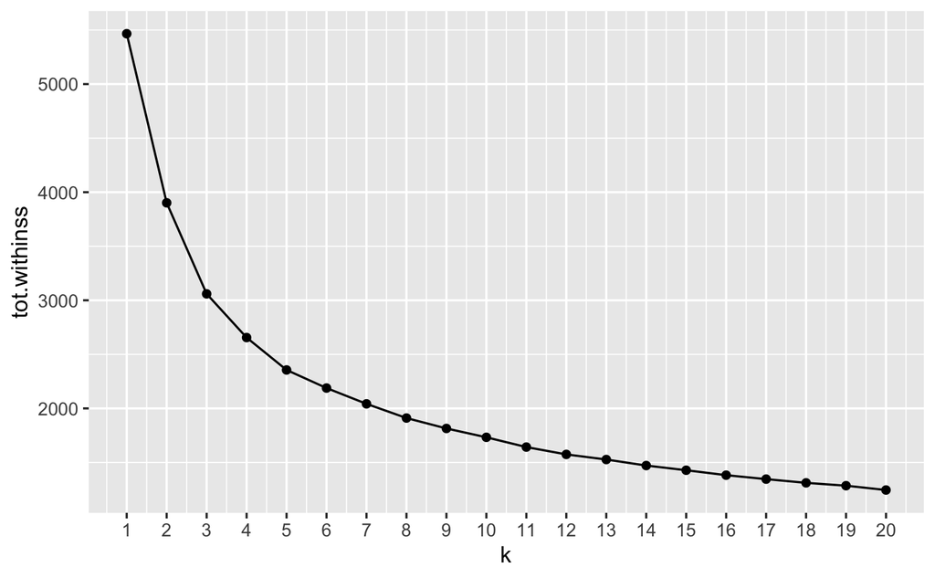

```r
k_clusters %>%
  ggplot(aes(x = k,
             y = tot.withinss))+
  geom_point()+
  geom_line()+
  scale_x_continuous(breaks = seq(1,20,1))
```

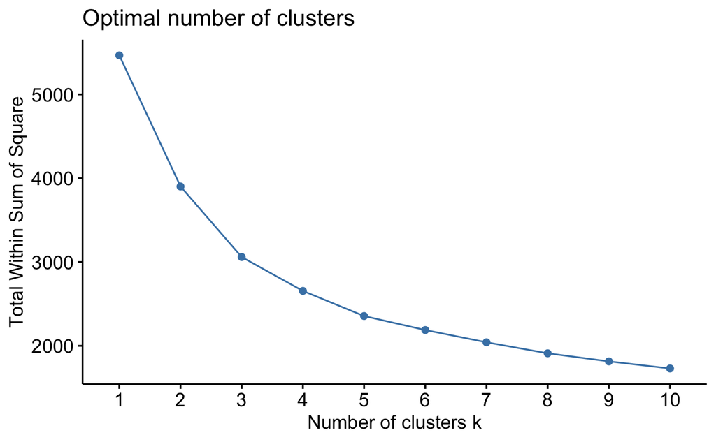

```r
library(factoextra)
fviz_nbclust(student_short,
             kmeans,
             method = "wss",
             nstart = 25)
```

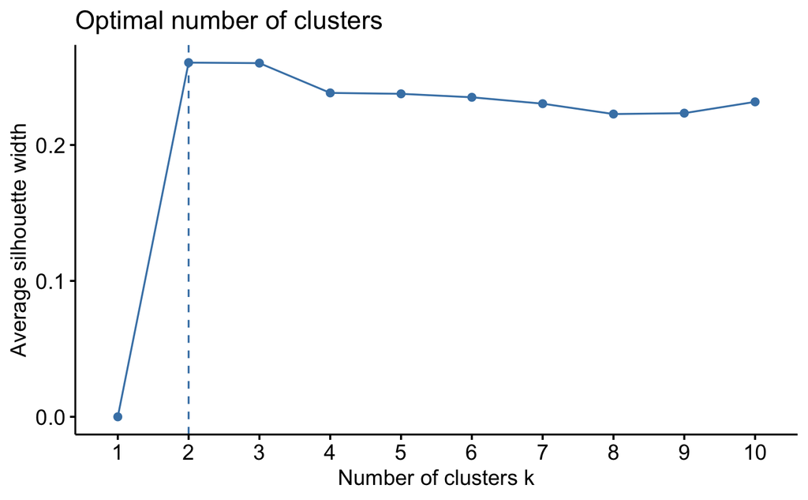

```r
fviz_nbclust(student_short,
             kmeans,
             method = "silhouette",
             nstart = 25)
```

[output not shown]

[output not shown]

[output not shown]

[output not shown]

[output not shown]

[output not shown]

[output not shown]

[output not shown]

[output not shown]

[output not shown]

[output not shown]

[output not shown]

[output not shown]

[output not shown]

[output not shown]

[output not shown]

[output not shown]

[output not shown]

[output not shown]

[output not shown]

[output not shown]

[output not shown]

[output not shown]

[output not shown]

[output not shown]

[output not shown]

[output not shown]

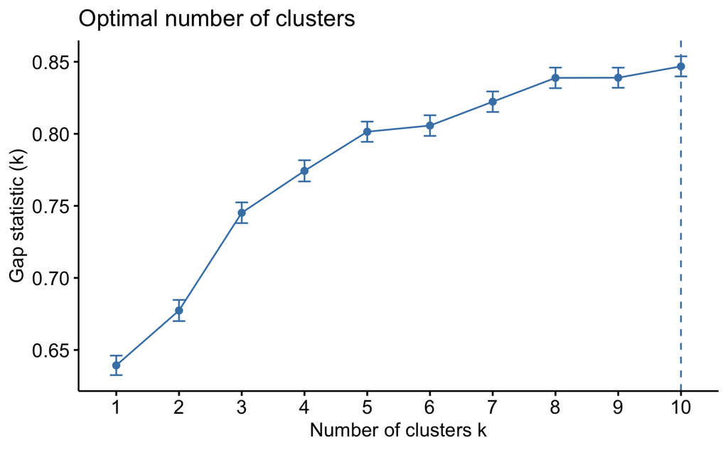

```r
fviz_nbclust(student_short,
             kmeans,
             method = "gap_stat",
             nstart = 25,
             k.max = 10)
```

doesn’t seem to be good ……

2 Part b We have been asked to cluster the variables which are asking about environmental questions (importance_reducing_pollution, importance_recycling_rubbish, importance_conserving_water, importance_saving_enery) into 2 clusters because the school wants to split the students into 2 groups to target with specific learning/lessons about environmental issues.

Once you have set up the 2 clusters visualise a combination of the variables split by the clusters (e.g. plot importance_reducing_pollution vs importance_recycling_rubbish etc.) how might you describe these 2 groups in terms of characteristics on views on environmental issues back to the school?

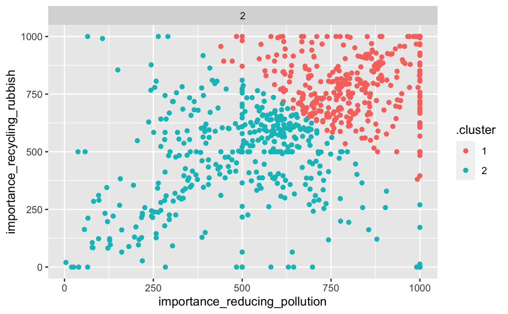